# Mapping Crimean-Congo Haemorrhagic Fever in Africa with BART

# Mapping CCHF

Alright. Now let’s get back to business by building the CCHF map. We’re going to use the same predictors as we used for *H. truncatum*, plus the suitability layer for the ticks. (Using one SDM layer in another map is a sort of finnicky business - sometimes it improves predictions and is epistemologically valid, other times it predetermines a certain outcome in the final model, given issues with colinearity. That’s a broader discussion than what we’re doing here! If the final map predicts some areas that aren’t where the ticks are, I’ll call that a win. If they were identical, I would worry.)

## Running the CCHF model

This time, let’s just do the variable selection up front. Same plan as before:

```r
# Update the covariate stack

covs <- stack(covs, hytr.layer)
names(covs)[12]='hytr' # for Hyalomma truncatum
xvars <- c(xvars, 'hytr')

# Read in the data

load(file = "~/Github/pier39/cchf.rda")
head(cchf)
```

|  | OCCURRENCE_ID | LOCATION_TYPE | ADMIN_LEVEL | GAUL_AD1 | GAUL_AD2 | UNIQUE_LOCATION | YEAR | LATITUDE | LONGITUDE | COUNTRY | REGION |
| --- | --- | --- | --- | --- | --- | --- | --- | --- | --- | --- | --- |
| 1 | 1 | point | -999 | 1282 | 16397 | 535 | 1953 | 38 | 69 | Tajikistan | Asia |
| 2 | 2 | point | -999 | 1282 | 16397 | 1178 | 1953 | 38 | 70 | Tajikistan | Asia |
| 3 | 3 | point | -999 | 1282 | 16397 | 620 | 1954 | 42 | 21 | Serbia | Asia |
| 4 | 4 | point | -999 | 1278 | 16376 | 1182 | 1954 | 37 | 69 | Tajikistan | Asia |
| 5 | 5 | point | -999 | 1278 | 16376 | 1165 | 1954 | 37 | 69 | Tajikistan | Asia |
| 6 | 6 | point | -999 | 1278 | 16376 | 1178 | 1954 | 38 | 70 | Tajikistan | Asia |

```r
nrow(cchf)
```

```
#> [1] 1721
```

```r
# Spatial thinning checks; this also limits it to African points (CCHF is found elsewhere in the world too, and our data includes other records!)

cchf <- cchf[,c('LONGITUDE','LATITUDE')]; cchf$Presence = 1
cchf <- SpatialPointsDataFrame(cchf[,1:2],data.frame(Presence=cchf[,3]))
tmp=rasterize(cchf, covs[[1]], field="Presence", fun="min")
pts.sp1=rasterToPoints(tmp, fun=function(x){x>0})
nrow(pts.sp1)
```

```
#> [1] 147
```

```r
# Extract presence values

pres.cov <- raster::extract(covs, pts.sp1[,1:2])
pres.cov <- na.omit(pres.cov)
head(pres.cov)
```

```
#>      bio1  bio12 bio13  bio14 bio15 bio2 bio5 bio6  crop ndvi.amp
#> [1,]   31 0.0076 0.011 0.0044  0.20   23   48  9.9 0.046    0.183
#> [2,]   31 0.0076 0.011 0.0044  0.21   23   48  9.9 0.009    0.101
#> [3,]   29 0.0106 0.016 0.0070  0.30   15   41 16.9 0.000    0.031
#> [4,]   31 0.0098 0.015 0.0053  0.33   21   46 14.7 0.036    0.019
#> [5,]   32 0.0085 0.014 0.0036  0.38   21   47 14.5 0.002    0.023
#> [6,]   31 0.0082 0.015 0.0032  0.43   20   47 13.3 0.048    0.025
#>      ndvi.mean  hytr
#> [1,]     0.033 0.015
#> [2,]     0.023 0.021
#> [3,]     0.069 0.193
#> [4,]     0.133 0.392
#> [5,]     0.124 0.127
#> [6,]     0.133 0.169
```

```r
#Generate pseudoabsences

absence <- randomPoints(covs,nrow(pres.cov))
abs.cov <- raster::extract(covs, absence)

#Code the response

pres.cov <- data.frame(pres.cov); pres.cov$cchf <- 1
abs.cov <- data.frame(abs.cov); abs.cov$cchf <- 0

# And one to bind them

all.cov <- rbind(pres.cov, abs.cov)
all.cov <- all.cov[complete.cases(all.cov),]; nrow(all.cov)
```

```
#> [1] 184
```

```r
head(all.cov)
```

|  | bio1 | bio12 | bio13 | bio14 | bio15 | bio2 | bio5 | bio6 | crop | ndvi.amp | ndvi.mean | hytr | cchf |
| --- | --- | --- | --- | --- | --- | --- | --- | --- | --- | --- | --- | --- | --- |
| 1 | 31 | 0.0076 | 0.011 | 0.0044 | 0.20 | 23 | 48 | 9.9 | 0.046 | 0.183 | 0.033 | 0.015 | 1 |
| 2 | 31 | 0.0076 | 0.011 | 0.0044 | 0.21 | 23 | 48 | 9.9 | 0.009 | 0.101 | 0.023 | 0.021 | 1 |
| 3 | 29 | 0.0106 | 0.016 | 0.0070 | 0.30 | 15 | 41 | 16.9 | 0.000 | 0.031 | 0.069 | 0.193 | 1 |
| 4 | 31 | 0.0098 | 0.015 | 0.0053 | 0.33 | 21 | 46 | 14.7 | 0.036 | 0.019 | 0.133 | 0.392 | 1 |
| 5 | 32 | 0.0085 | 0.014 | 0.0036 | 0.38 | 21 | 47 | 14.5 | 0.002 | 0.023 | 0.124 | 0.127 | 1 |
| 6 | 31 | 0.0082 | 0.015 | 0.0032 | 0.43 | 20 | 47 | 13.3 | 0.048 | 0.025 | 0.133 | 0.169 | 1 |

```
#>
#>  10 tree models: 5 iterations
#>
#>  20 tree models: 5 iterations
#>
#>  50 tree models: 5 iterations
#>
#>  100 tree models: 5 iterations
#>
#>  150 tree models: 5 iterations
#>
#>  200 tree models: 5 iterations
```

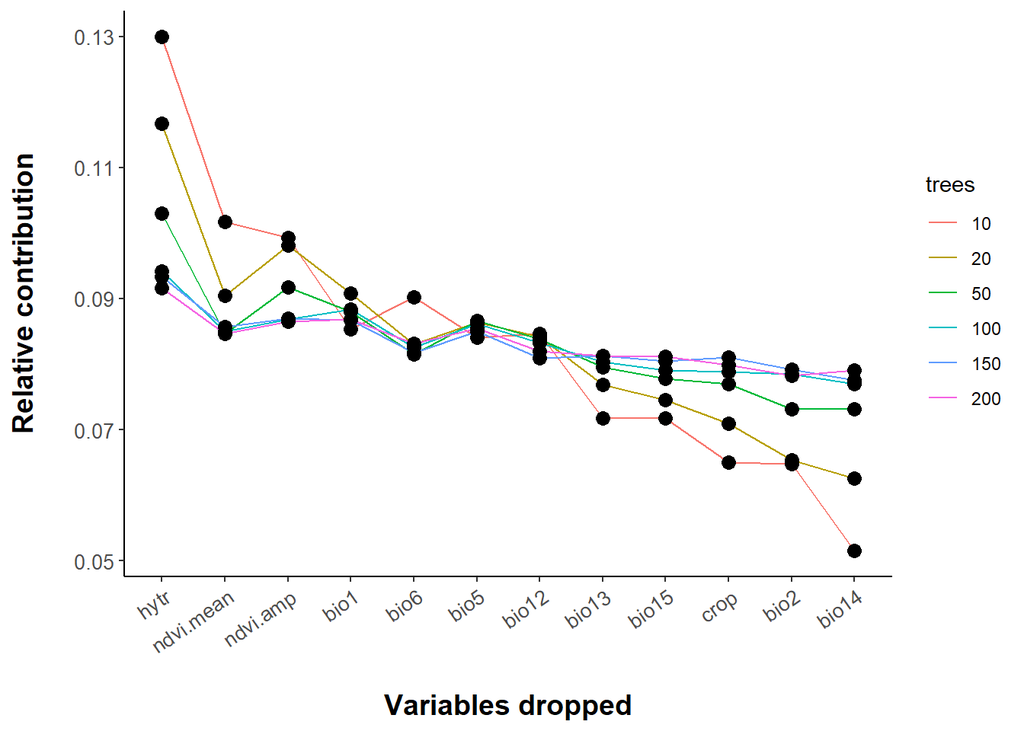

```
#> [1] Number of variables included: 12
#> [1] Dropped:
#> [1]
#> [1] ---------------------------------------
#> [1] Number of variables included: 11
#> [1] Dropped:
#> [1] crop
#> [1] ---------------------------------------
#> [1] Number of variables included: 10
#> [1] Dropped:
#> [1] crop  bio14
#> [1] ---------------------------------------
#> [1] Number of variables included: 9
#> [1] Dropped:
#> [1] crop  bio14 bio2
```

[output cut: 27 more lines]

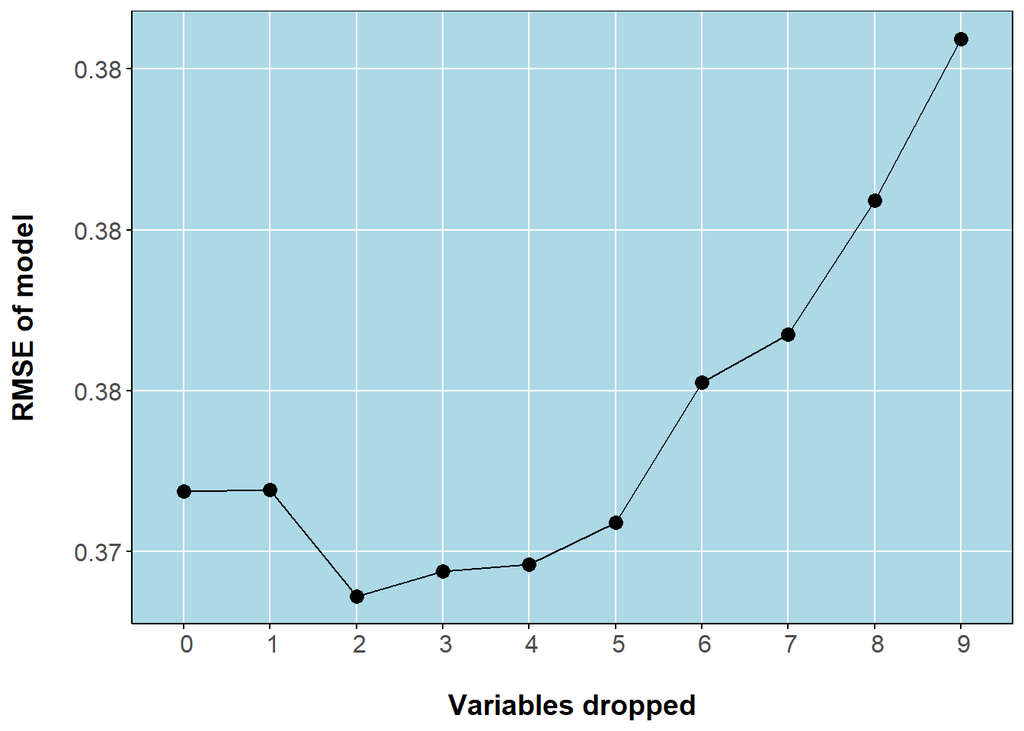

```
#> [1] ---------------------------------------
#> [1] Final recommended variable list
#>  [1] bio1      bio12     bio13     bio15     bio2      bio5      bio6
#>  [8] ndvi.amp  ndvi.mean hytr
#>
#> Running BART with binary y
#>
#> number of trees: 200
#> number of chains: 1, number of threads 1
#> Prior:
#>  k: 2.000000
#>  power and base for tree prior: 2.000000 0.950000
#>  use quantiles for rule cut points: false
#> data:
#>  number of training observations: 184
#>  number of test observations: 0
#>  number of explanatory variables: 10
#>
#> Cutoff rules c in x<=c vs x>c
#> Number of cutoffs: (var: number of possible c):
#> (1: 100) (2: 100) (3: 100) (4: 100) (5: 100)
#> (6: 100) (7: 100) (8: 100) (9: 100) (10: 100)
#>
#>
#> offsets:
#>  reg : 0.00 0.00 0.00 0.00 0.00
#> Running mcmc loop:
#> iteration: 100 (of 1000)
#> iteration: 200 (of 1000)
#> iteration: 300 (of 1000)
#> iteration: 400 (of 1000)
#> iteration: 500 (of 1000)
#> iteration: 600 (of 1000)
#> iteration: 700 (of 1000)
#> iteration: 800 (of 1000)
#> iteration: 900 (of 1000)
#> iteration: 1000 (of 1000)
#> total seconds in loop: 1.422197
#>
#> Tree sizes, last iteration:
#> [1] 2 4 2 2 2 3 3 1 3 2 3 3 2 2 2 3 3 2
#> 3 2 2 3 3 2 2 4 2 2 2 2 2 2 2 3 1 3 3 2
#> 1 2 2 2 2 2 2 2 2 2 4 1 1 3 3 3 4 1 2 2
#> 2 2 2 3 2 2 3 2 2 2 3 2 3 2 2 2 2 2 3 2
#> 3 2 2 2 2 2 2 2 2 2 2 2 2 2 2 2 3 2 2 2
#> 2 3 2 2 4 2 3 2 2 3 2 4 3 2 2 2 3 2 2 3
#> 2 2 2 2 3 2 2 2 2 3 2 3 2 3 2 2 3 2 3 2
#> 2 3 3 2 2 2 4 2 2 2 2 2 2 3 3 2 2 3 4 3
#> 1 2 3 2 2 2 3 1 2 2 2 2 2 1 2 2 3 2 3 1
#> 2 2 2 2 2 2 3 2 2 2 2 2 2 2 2 3 2 2 2 2
#> 3 2
#>
#> Variable Usage, last iteration (var:count):
#> (1: 32) (2: 34) (3: 26) (4: 19) (5: 23)
#> (6: 29) (7: 24) (8: 25) (9: 16) (10: 26)
#>
#> DONE BART
```

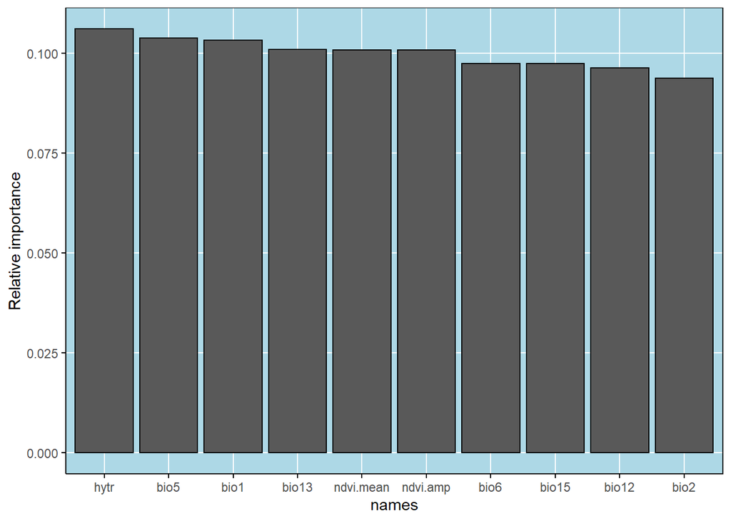

[output not shown]

[figure not shown]

```r
# This part automates the variable selection and returns the model

cchf.model <- bart.step(xdata = all.cov[,xvars],
                        ydata = all.cov[,'cchf'],
                        full = TRUE,
                        iter.plot = 5,
                        iter.step = 10,
                        quiet = TRUE)
```

OK. Nice model! Let’s see what we can do to unpack it.

First, let’s compare it against the tick map.

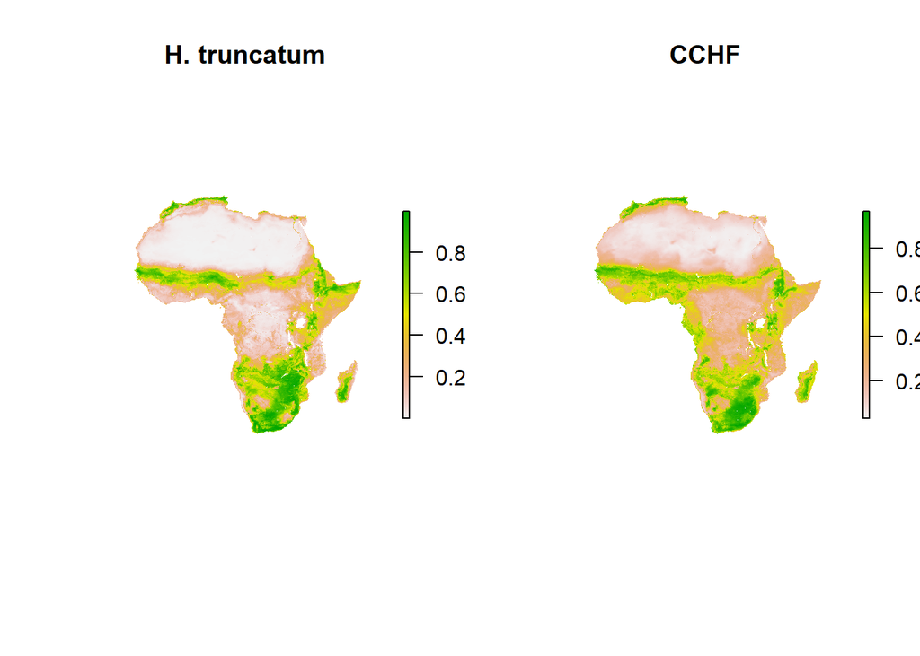

```r
par(mfrow=c(1,2))
plot(hytr.layer, box=FALSE, axes=FALSE, main='H. truncatum')
plot(cchf.map[[1]], box=FALSE, axes=FALSE, main='CCHF')
```

Our model seems to be different from the previous one (published by Messina *et al.*, using this dataset which they generously provide online) in three major ways.

1. First, using the tick vector has increased the amount of predicted suitable area in South Africa, Namibia, Botswana, and Zimbabwe. That makes sense, overall–if there are vectors present, CCHF seems plausible.
2. The model predicts the area in coastal Cameroon, Gabon, and Equatorial Guinea that we know has some CCHF records but has previously been underpredicted. Weirdly, we don’t have good evidence *Hyalomma truncatum* is there. So, the model is doing well, but the ecology is still unclear.
3. Finally, the northern coast of Africa is predicted to be highly suitable. There’s plenty of *Hyalomma* species up there, though not *H. truncatum* as far as our data suggests. It’s possible we should think more about the possibility of CCHF in Morocco and Algeria.

Let’s take a look at the uncertainty in the model:

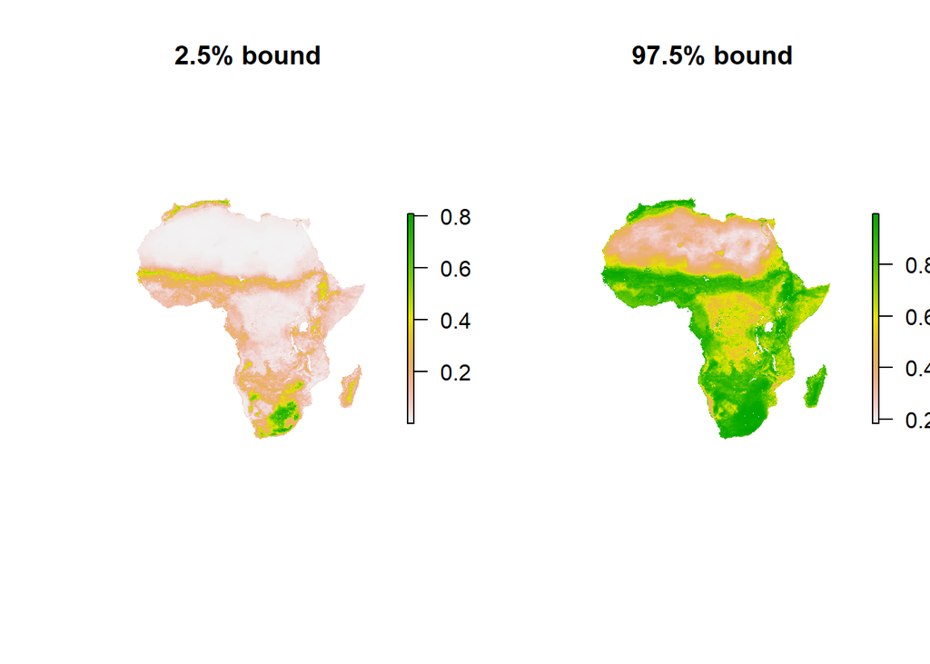

```r
par(mfrow=c(1,2))
plot(cchf.map[[2]], box=FALSE, axes=FALSE, main='2.5% bound')
plot(cchf.map[[3]], box=FALSE, axes=FALSE, main='97.5% bound')
```

This may be more interesting to think about in the context of binary maps of presence/absence. We can produce those using `summary`:

```r
summary(cchf.model)
```

```
#> Call:  bart xdata[, vs] ydata TRUE
#>
#> Predictor list:
#>  bio1 bio12 bio13 bio15 bio2 bio5 bio6 ndvi.amp ndvi.mean hytr
#>
#> Area under the receiver-operator curve
#> AUC = 0.91
#>
#> Recommended threshold (maximizes true skill statistic)
#> Cutoff =  0.55
#> TSS =  0.65
#> Resulting type I error rate:  0.24
#> Resulting type II error rate:  0.11
```

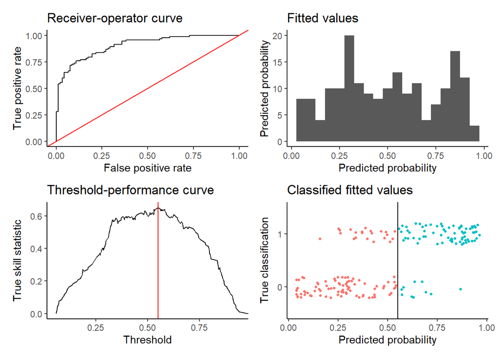

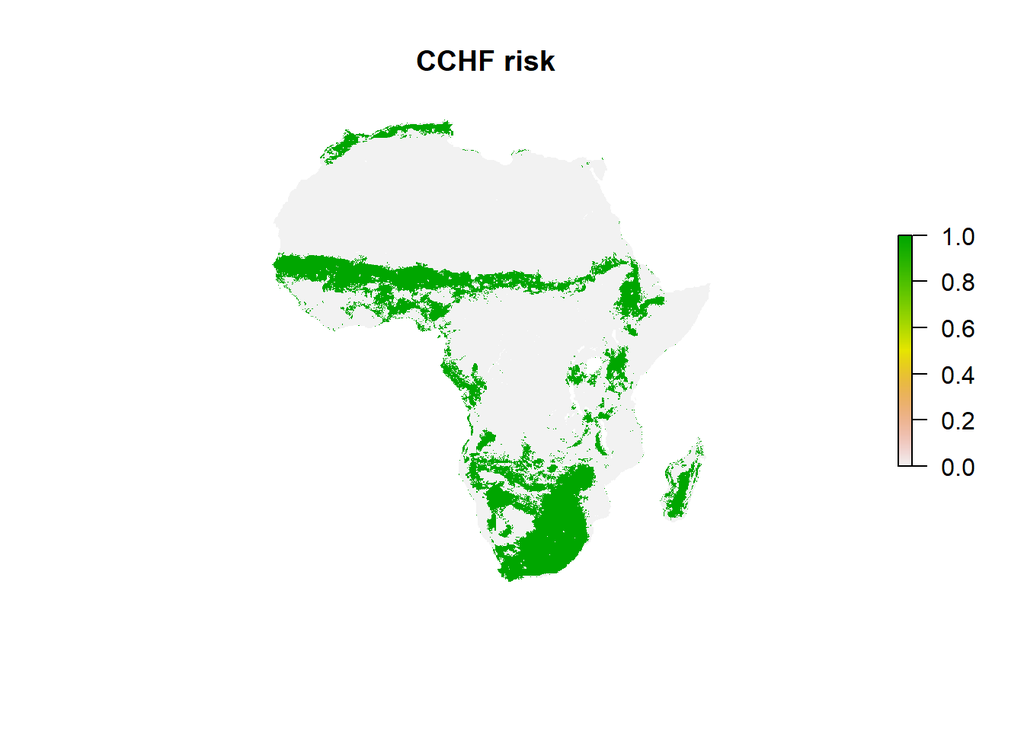

```r
par(mfrow=c(1,1))
plot(cchf.map[[1]]>0.55, box=FALSE, axes=FALSE, main='CCHF risk')
```

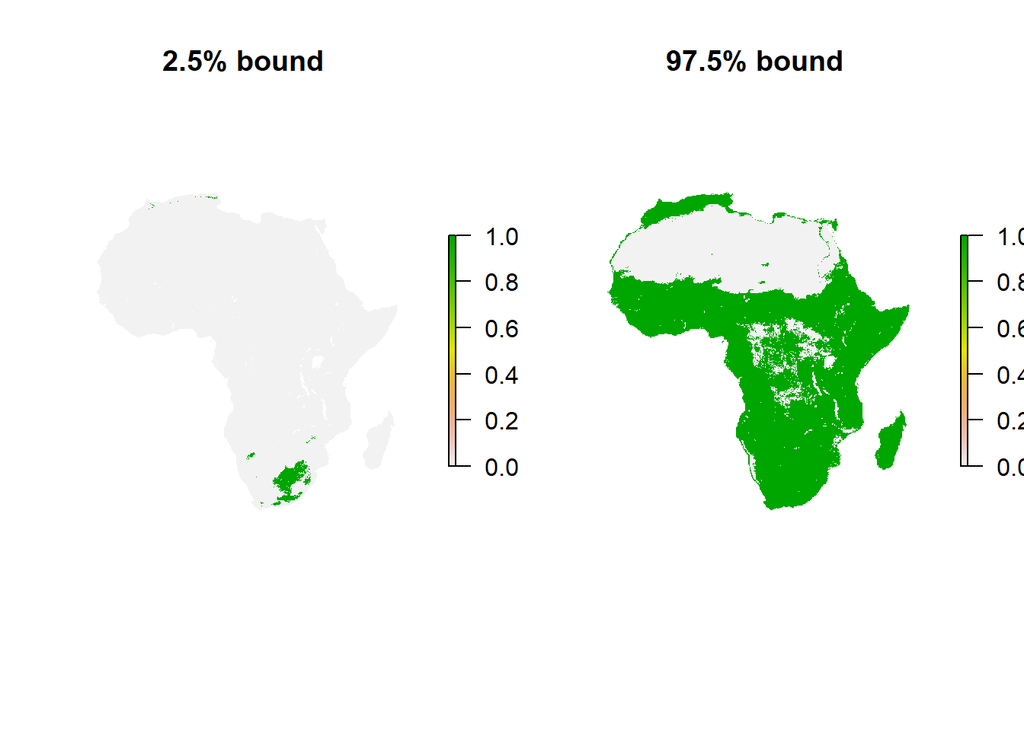

```r
par(mfrow=c(1,2))
plot(cchf.map[[2]]>0.55, box=FALSE, axes=FALSE, main='2.5% bound')
plot(cchf.map[[3]]>0.55, box=FALSE, axes=FALSE, main='97.5% bound')
```

The outer bounds here are *incredibly* wide - which highlights exactly how little data we have about the distribution of CCHF, and how much uncertainty presentation matters.

Where is the uncertainty highest?

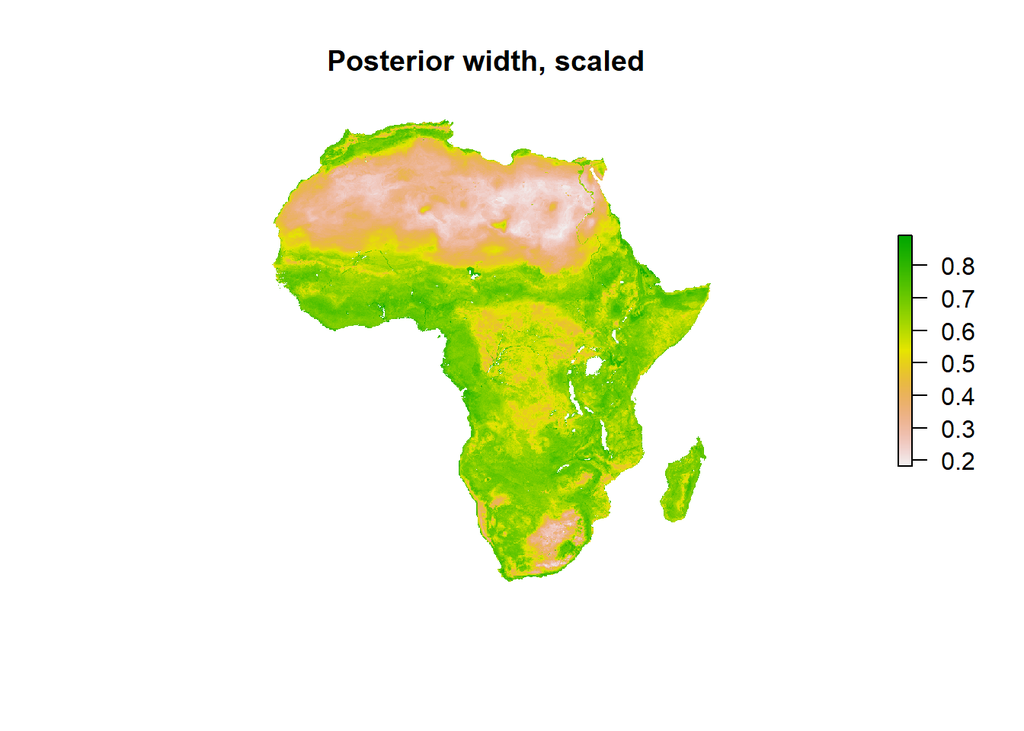

```r
par(mfrow=c(1,1))
plot(cchf.map[[3]]-cchf.map[[2]],
     box=FALSE, axes=FALSE, main='Posterior width, scaled')
```

Posterior width isn’t always the most informative measure of uncertainty. But it does tell us we’re most confident in the Sahara, where we’re quite sure there’s no real CCHF risk, and in the parts of South Africa where spillover is most common. We can further investigate by mapping the places with the most uncertainty:

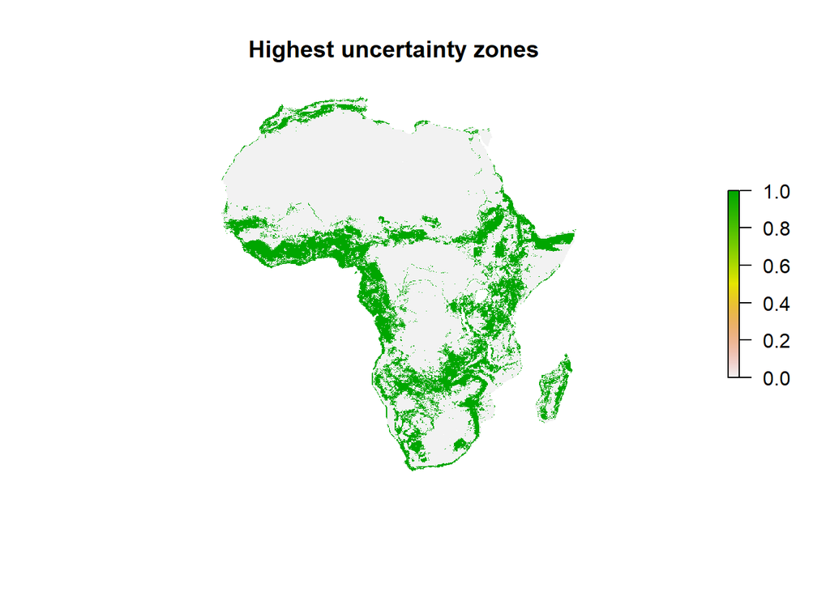

```r
quant <- quantile(values(cchf.map[[3]]-cchf.map[[2]]), 0.75, na.rm=TRUE)

par(mfrow=c(1,1))
plot((cchf.map[[3]]-cchf.map[[2]])>quant,
     box=FALSE, axes=FALSE,
     main = "Highest uncertainty zones")
```

The most interesting takehome is that uncertainty is particularly high on the Western coast of Africa; along the equator, CCHF spillover has previously occurred but the tick vector is absent. This may be worth further investigation. Similarly, there are no spillovers along the southern coast of Africa, but uncertainty is very high, and it may be worth investigating this more (especially given tick records in that region).

## Analytics

Finally, let’s unpack some of what’s under the hood in the model. First let’s look at the variable contributions:

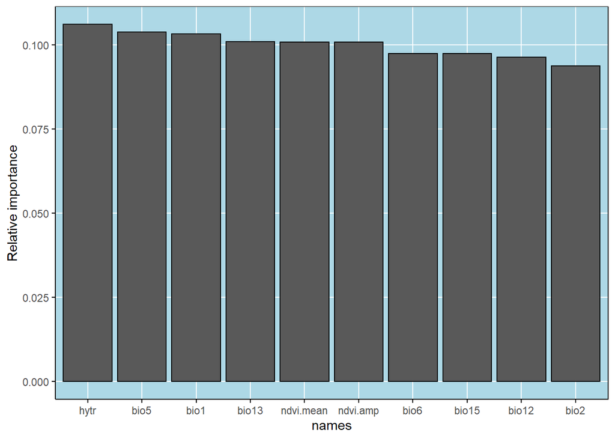

| names | varimps |
| --- | --- |
| bio1 | 0.103 |
| bio12 | 0.096 |
| bio13 | 0.101 |
| bio15 | 0.097 |
| bio2 | 0.094 |
| bio5 | 0.104 |
| bio6 | 0.097 |
| ndvi.amp | 0.101 |
| ndvi.mean | 0.101 |
| hytr | 0.106 |

```r
varimp(cchf.model, plots=TRUE)
```

The tick vector come out on top, unsurprisingly! Let’s look at the response functions a little bit. First, let’s look at the partial dependence plots for a couple individual variables.

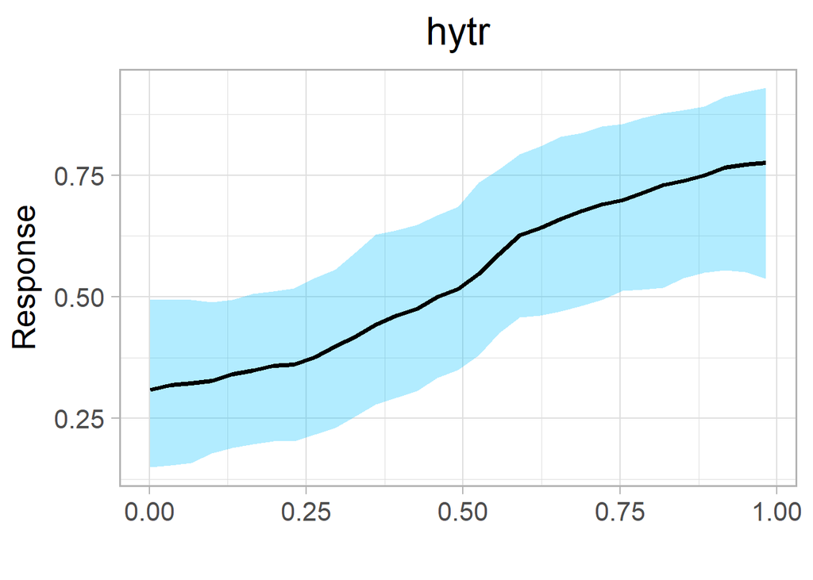

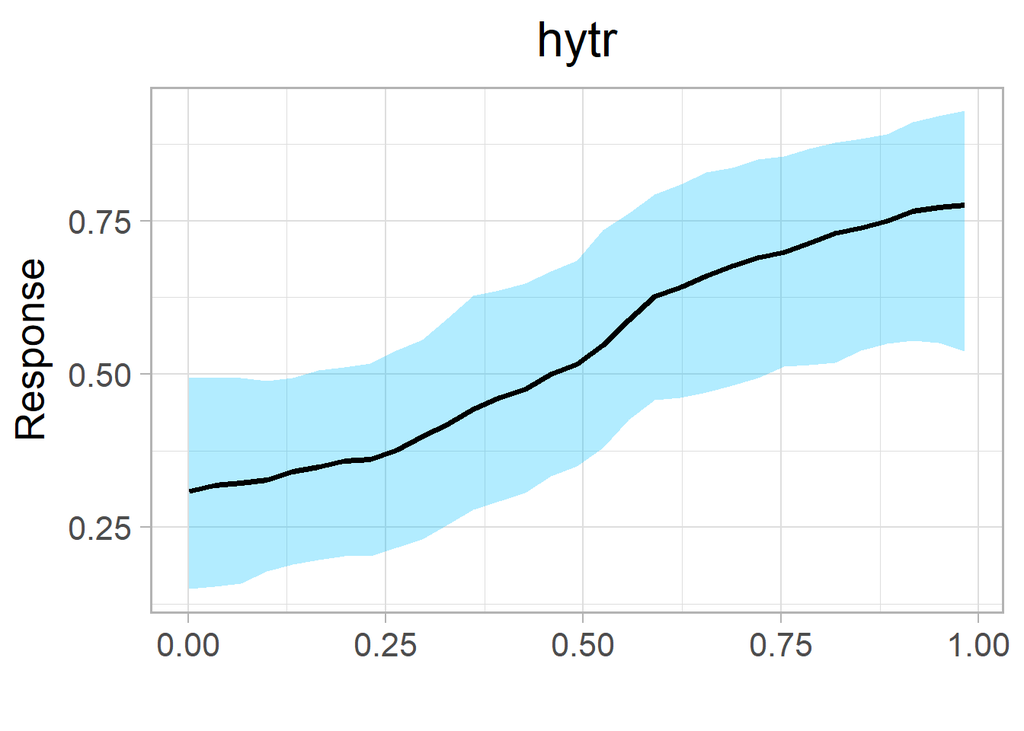

```r
# Let's check the tick response curve
partial(cchf.model,
        'hytr',
        trace=FALSE,
        ci=TRUE,
        equal=TRUE,
        smooth=3)
```

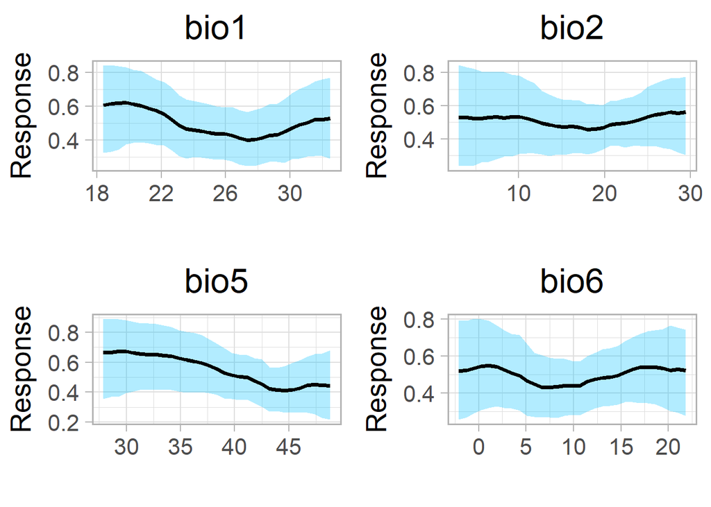

```r
# Let's do all of them at once
partial(cchf.model,
        c('bio1','bio2','bio5','bio6'),
        trace=FALSE,
        ci=TRUE,
        panel=TRUE,
        smooth=3)
```

Some of these patterns are pretty clear - suitability declines above 20 degrees C, and increases with the probability of the tick. NDVI is a little less intuitive to the human mind, but a great feature of BART is that we can pretty easily do two-dimensional partial dependence plots, and we can pretty easily visualize the optimum (I haven’t added a wrapper for this yet):

```r
p <- pd2bart(cchf.model, xind=c('ndvi.mean', 'ndvi.amp'), pl=TRUE)
```

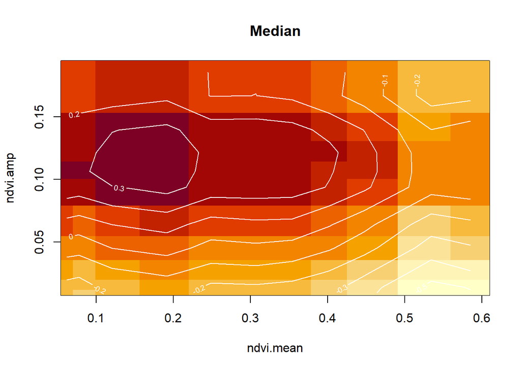

This is probably my favorite feature of - these plots are a really nice way to visualize the Hutchinsonian niche sort of like how NicheA does, but within the familiar framework of classification trees. Plus it’s not just a cross-product of the individual partials - the BART framework allows for interactions and sometimes you’ll see them show up in these plots.

One last cool trick: spatial partial dependence plots

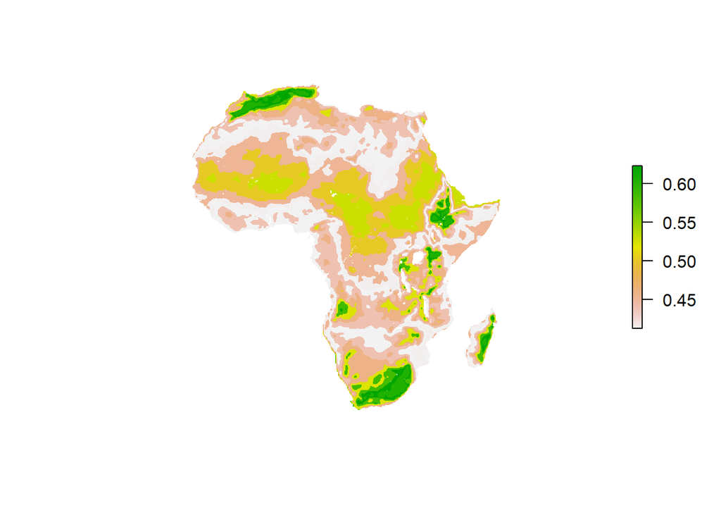

```
#> class      : RasterStack
#> dimensions : 867, 999, 866133, 1  (nrow, ncol, ncell, nlayers)
#> resolution : 0.083, 0.083  (x, y)
#> extent     : -25, 58, -35, 37  (xmin, xmax, ymin, ymax)
#> crs        : NA
#> names      : bio1
#> min values : 0.41
#> max values : 0.62
```

```r
spartial(cchf.model, covs, x.vars = 'bio1', equal=TRUE)
```

This map projects the partial dependence plot onto the raster data for the bio1 layer, and can be interpreted as answering the question “Where are mean temperatures most conducive for viral transmission?”

# Finally…

A big thanks to Jane Messina *et al.* for publicly sharing their CCHF data, and to Graeme Cumming for tick data.

# References

- Carlson, C.J., *et al.* “The global distribution of Bacillus anthracis and associated anthrax risk to humans, livestock and wildlife.” Nature Microbiology (2019): *in press*.
- Cumming, G. S. “Host preference in African ticks (Acari: Ixodida): a quantitative data set.” *Bulletin of Entomological Research* 88.4 (1998): 379-406.
- Hijmans, R.J., *et al.* “Very high resolution interpolated climate surfaces for global land areas.” *International Journal of Climatology: A Journal of the Royal Meteorological Society* 25.15 (2005): 1965-1978.
- Messina, Jane P., *et al.* “A global compendium of human Crimean-Congo haemorrhagic fever virus occurrence.” *Scientific Data* 2 (2015): 150016.
- Messina, Jane P., *et al.* “The global distribution of Crimean-Congo hemorrhagic fever.” *Transactions of the Royal Society of Tropical Medicine and Hygiene* 109.8 (2015): 503-513.